# Assignment - Bike Station Deficits/Gains

Alexis Alexander

16 November 2023

This experiment continues on to our analysis on the DC Bikeshare Project. We are using the most recent September data from DC Capital Bikeshare, which can be obtained by following this link: https://s3.amazonaws.com/capitalbikeshare-data/index.html.

### Load the Necessary Data Packages

Baseline packages for our analysis

```r
library(tidyverse)
library(janitor)
library(here)
library(openmeteo)
```

# Loading the Bikeshare Raw Data

```r
df1 <- read_csv("data_raw/202309-capitalbikeshare-tripdata.csv", show_col_types = FALSE) %>% clean_names()
```

Before working on the new goal of this analysis, all previous manipulations to the data set from previous labs have been applied as well.

# Creating Dataframe 2 - Interjoing

```r
df2s=df1 %>%
  select(rideable_type,member_casual,
                    contains("start"),ride_id)%>%
  mutate(start_stop="start")%>%
  rename(t=started_at,
        station_name=start_station_name,
        station_id=start_station_id,
        lat=start_lat,
        lng=start_lng)

df2e=df1 %>%
select(ride_id,rideable_type,member_casual,
                    contains("end")) %>%
  mutate(start_stop="stop") %>%
  rename(t=ended_at,
        station_name=end_station_name,
        station_id=end_station_id,
        lat=end_lat,
        lng=end_lng)

df2=bind_rows(df2s,df2e) %>%
  arrange(t) %>%
  mutate(rider_delta=(start_stop=="start")*2-1) %>% #change in ridership
  mutate(riders=cumsum(rider_delta)) %>%
  relocate(riders,.after=t)
```

# Applying to Previously Determined Manipulations from Prior Analysis to the Entire Data Set

```r
df_r=df2 |>
  mutate(t_f=floor_date(t,"10 mins")) %>%
  relocate(t_f,.after=t) %>%
  slice_head(n=1,by=t_f)
```

## Get Weather Data using weather_history

```r
df_w=weather_history("Washington",
                    start = "2023-09-01",
                    end = "2023-09-30",
                    hourly = c("apparent_temperature",
                            "wind_speed_10m",
                            "precipitation"))
```

```
`geocode()` has matched "Washington" to:
Washington in Washington, D.C., United States
Population: 601723
Co-ordinates: c(38.89511, -77.03637)
```

# Merging Bike and Weather Data

```r
df_s=df2 %>% slice_sample(n=1000)
df_j=df_s %>% left_join(df_w,
                        by=join_by(closest(t>=datetime)))
```

```r
df_j=df_s %>%
   left_join(df_w,by=join_by(closest(t>=datetime)))  %>%
   relocate(datetime, .after=t)

head(df_j)
```

| rideable_type | member_casual | t | datetime | riders | station_name | station_id | lat | lng | ride_id | start_stop | rider_delta | hourly_apparent_temperature | hourly_wind_speed_10m | hourly_precipitation |
| --- | --- | --- | --- | --- | --- | --- | --- | --- | --- | --- | --- | --- | --- | --- |
| electric_bike | casual | 2023-09-26 17:18:34 | 2023-09-26 13:00:00 | 335 | Rhode Island Ave Metro | 31516 | 38.92072 | -76.99599 | 446391611C738360 | start | 1 | 15.6 | 16.8 | 0.1 |
| classic_bike | member | 2023-09-01 16:07:04 | 2023-09-01 12:00:00 | 433 | 10th & H St NE | 31672 | 38.89998 | -76.99272 | 46F6313511E09A89 | start | 1 | 26.9 | 5.8 | 0.0 |
| classic_bike | member | 2023-09-20 14:11:01 | 2023-09-20 10:00:00 | 222 | 20th & L St NW | 31250 | 38.90358 | -77.04479 | 27BCA02C19A96060 | stop | -1 | 22.9 | 1.8 | 0.0 |
| electric_bike | member | 2023-09-19 08:45:03 | 2023-09-19 04:00:00 | 366 | NA | NA | 38.90000 | -77.04000 | 4718C69D72F590BD | stop | -1 | 13.9 | 11.8 | 0.0 |
| classic_bike | member | 2023-09-05 13:12:35 | 2023-09-05 09:00:00 | 182 | 8th & H St NE | 31661 | 38.89994 | -76.99490 | DF4F8E6080F9DE76 | start | 1 | 32.9 | 12.3 | 0.0 |
| classic_bike | member | 2023-09-20 09:57:35 | 2023-09-20 05:00:00 | 215 | Glebe Rd & 11th St N | 31038 | 38.88392 | -77.11682 | EE611494741AE6C7 | stop | -1 | 11.8 | 5.4 | 0.0 |

## Investigating the Time Zone Mismatch Between the Bikeshare and Weather Datasets

```r
df2c=df2 %>% mutate(t=force_tz(t,tzone="America/New_York")) #corrected

df_s2=df2c %>% slice_sample(n=1000)

df_j2=df_s2 %>%
   left_join(df_w,by=join_by(closest(t>=datetime)))  %>%
   relocate(datetime, .after=t)

head(df_j2)
```

| rideable_type | member_casual | t | datetime | riders | station_name | station_id | lat | lng | ride_id | start_stop | rider_delta | hourly_apparent_temperature | hourly_wind_speed_10m | hourly_precipitation |
| --- | --- | --- | --- | --- | --- | --- | --- | --- | --- | --- | --- | --- | --- | --- |
| classic_bike | member | 2023-09-25 14:41:30 | 2023-09-25 14:00:00 | 190 | M St & Delaware Ave NE | 31627 | 38.90569 | -77.00320 | 07C74DD6484EB14C | start | 1 | 20.6 | 10.1 | 0 |
| classic_bike | member | 2023-09-07 17:05:30 | 2023-09-07 17:00:00 | 338 | 25th St & Pennsylvania Ave NW | 31237 | 38.90383 | -77.05348 | 838088546D228B97 | start | 1 | 35.5 | 7.1 | 0 |
| classic_bike | member | 2023-09-16 22:38:57 | 2023-09-16 22:00:00 | 248 | 4th & M St SE | 31652 | 38.87675 | -77.00074 | 56E88F27F42349C2 | stop | -1 | 17.0 | 7.9 | 0 |
| classic_bike | member | 2023-09-21 07:43:44 | 2023-09-21 07:00:00 | 216 | 4th & M St SE | 31652 | 38.87675 | -77.00074 | 9C95EB097A8D1778 | stop | -1 | 15.4 | 8.9 | 0 |
| docked_bike | casual | 2023-09-01 19:12:44 | 2023-09-01 19:00:00 | 410 | 12th St & New York Ave NW | 31670 | 38.90110 | -77.02806 | 550BA1831B09B5D8 | stop | -1 | 20.3 | 9.2 | 0 |
| classic_bike | casual | 2023-09-02 19:37:53 | 2023-09-02 19:00:00 | 460 | 8th & O St NW | 31281 | 38.90864 | -77.02277 | 26490E2FA9A4B322 | start | 1 | 25.7 | 9.5 | 0 |

```r
dfc=df2c %>%
  left_join(df_w,by=join_by(closest(t>=datetime))) %>%
   relocate(datetime, .after=t) %>%
  rename(atemp=hourly_apparent_temperature,
         wind=hourly_wind_speed_10m,
         prec=hourly_precipitation)
```

```r
df1_duration = df1 |>
  mutate(ride_time = ended_at-started_at)
```

Now that all our previous analysis have been loaded, we will move on attempting to remove any data where the start time is after the end time.

# Removing any Data for Which Start Time is After End Time

```r
dfb = df1 %>%
  filter(started_at<ended_at)
```

## Create a Dataframe that Counts the Number of “Starts” from each Station ID

```r
df_starts_test = dfb %>%
  slice_tail(n=500) %>%
  group_by(start_station_id) %>%
  count(start_station_id)
  # summarise(n = n(start_station_name))
head(df_starts)
```

[output not shown]

```r
NA
```

### Applying Code to the Entire Data Set

```r
df_starts = dfb %>%
  group_by(start_station_id,start_station_name) %>%
  count(start_station_id)
head(df_starts)
```

| start_station_id | start_station_name | n |
| --- | --- | --- |
| 30200 | 9th St & Pennsylvania Ave NW | 1068 |
| 30201 | 9th & G St NW | 1216 |
| 31000 | Eads St & 15th St S | 403 |
| 31002 | Crystal Dr & 20th St S | 461 |
| 31003 | Crystal Dr & 15th St S | 560 |
| 31004 | Aurora Hills Cmty Ctr / 18th St & S Hayes St | 193 |

```r
NA
```

## Create a Dataframe that Counts the Number of “Ends” from each Station ID

```r
df_ends = dfb %>%
  group_by(end_station_id) %>%
  count(end_station_id)
head(df_ends)
```

| end_station_id | n |
| --- | --- |
| 30200 | 1363 |
| 30201 | 1272 |
| 31000 | 405 |
| 31002 | 460 |
| 31003 | 555 |
| 31004 | 194 |

## Join the Two Dataframes Together (df_starts and df_ends)

```r
df_net = df_starts %>%
  left_join(df_ends, by=join_by(start_station_id==end_station_id))  %>%
  rename(station_id = start_station_id,
         station_name = start_station_name,
         station_start_count = n.x,
         station_end_count =  n.y)
head(df_net)
```

| station_id | station_name | station_start_count | station_end_count |
| --- | --- | --- | --- |
| 30200 | 9th St & Pennsylvania Ave NW | 1068 | 1363 |
| 30201 | 9th & G St NW | 1216 | 1272 |
| 31000 | Eads St & 15th St S | 403 | 405 |
| 31002 | Crystal Dr & 20th St S | 461 | 460 |
| 31003 | Crystal Dr & 15th St S | 560 | 555 |
| 31004 | Aurora Hills Cmty Ctr / 18th St & S Hayes St | 193 | 194 |

```r
NA
```

## Compute the “Net Gain” (Arrivals-Departures from Each Station)

```r
df_netc = df_net %>%
  mutate(net_gain = station_end_count - station_start_count)
head(df_netc)
```

| station_id | station_name | station_start_count | station_end_count | net_gain |
| --- | --- | --- | --- | --- |
| 30200 | 9th St & Pennsylvania Ave NW | 1068 | 1363 | 295 |
| 30201 | 9th & G St NW | 1216 | 1272 | 56 |
| 31000 | Eads St & 15th St S | 403 | 405 | 2 |
| 31002 | Crystal Dr & 20th St S | 461 | 460 | -1 |
| 31003 | Crystal Dr & 15th St S | 560 | 555 | -5 |
| 31004 | Aurora Hills Cmty Ctr / 18th St & S Hayes St | 193 | 194 | 1 |

```r
NA
```

## Perform Exploratory Analysis (e.g Visualization) on the Resultant Dataframe

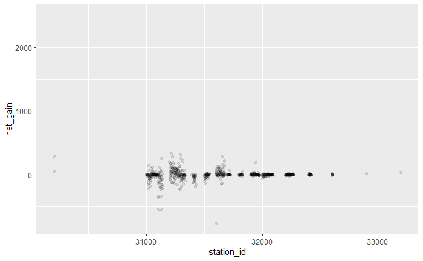